# Prediction Of exercise manner

Wu Wei

## Library input & Data Input

```r
library(parallel, warn.conflicts = FALSE, quietly = TRUE)
suppressMessages(library(doParallel, warn.conflicts = FALSE, quietly = TRUE))
library(ggplot2, warn.conflicts = FALSE, quietly = TRUE)
suppressMessages(library(randomForest, warn.conflicts = FALSE, quietly = TRUE, verbose = FALSE))
library(survival, warn.conflicts = FALSE, quietly = TRUE)
library(splines, warn.conflicts = FALSE, quietly = TRUE)
library(plyr, warn.conflicts = FALSE, quietly = TRUE)
suppressMessages(library(gbm, warn.conflicts = FALSE, quietly = TRUE, verbose = FALSE))
library(caret, warn.conflicts = FALSE, quietly = TRUE)

original.data <- read.csv("pml-training.csv")
```

## Exploratory Data Analysis

```r
dim(original.data)
```

```
## [1] 19622   160
```

```r
set.seed(88)
col.index <- sample(names(original.data), 20)
summary(original.data[col.index])
```

```
##   magnet_arm_x    skewness_yaw_belt accel_dumbbell_z  max_picth_arm
##  Min.   :-584.0          :19216     Min.   :-334.00   Min.   :-173.000
##  1st Qu.:-300.0   #DIV/0!:  406     1st Qu.:-142.00   1st Qu.:  -1.975
##  Median : 289.0                     Median :  -1.00   Median :  23.250
##  Mean   : 191.7                     Mean   : -38.32   Mean   :  35.751
##  3rd Qu.: 637.0                     3rd Qu.:  38.00   3rd Qu.:  95.975
##  Max.   : 782.0                     Max.   : 318.00   Max.   : 180.000
##                                                       NA's   :19216
##  accel_forearm_y  accel_forearm_z   new_window  accel_dumbbell_y
##  Min.   :-632.0   Min.   :-446.00   no :19216   Min.   :-189.00
##  1st Qu.:  57.0   1st Qu.:-182.00   yes:  406   1st Qu.:  -8.00
##  Median : 201.0   Median : -39.00               Median :  41.50
##  Mean   : 163.7   Mean   : -55.29               Mean   :  52.63
##  3rd Qu.: 312.0   3rd Qu.:  26.00               3rd Qu.: 111.00
##  Max.   : 923.0   Max.   : 291.00               Max.   : 315.00
##
##  var_accel_dumbbell avg_yaw_forearm   amplitude_yaw_arm
##  Min.   :  0.000    Min.   :-155.06   Min.   : 0.00
##  1st Qu.:  0.378    1st Qu.: -26.26   1st Qu.:13.00
##  Median :  1.000    Median :   0.00   Median :22.00
##  Mean   :  4.388    Mean   :  18.00   Mean   :20.79
##  3rd Qu.:  3.434    3rd Qu.:  85.79   3rd Qu.:28.75
##  Max.   :230.428    Max.   : 169.24   Max.   :52.00
##  NA's   :19216      NA's   :19216     NA's   :19216
##  stddev_yaw_dumbbell amplitude_pitch_arm var_total_accel_belt
##  Min.   :  0.000     Min.   :  0.000     Min.   : 0.000
##  1st Qu.:  3.885     1st Qu.:  9.925     1st Qu.: 0.100
##  Median : 10.264     Median : 54.900     Median : 0.200
##  Mean   : 16.647     Mean   : 69.677     Mean   : 0.926
##  3rd Qu.: 24.674     3rd Qu.:115.175     3rd Qu.: 0.300
##  Max.   :107.088     Max.   :360.000     Max.   :16.500
##  NA's   :19216       NA's   :19216       NA's   :19216
##  raw_timestamp_part_2    yaw_arm          skewness_roll_belt
##  Min.   :   294       Min.   :-180.0000            :19216
##  1st Qu.:252912       1st Qu.: -43.1000   #DIV/0!  :    9
##  Median :496380       Median :   0.0000   0.000000 :    4
##  Mean   :500656       Mean   :  -0.6188   0.422463 :    2
##  3rd Qu.:751891       3rd Qu.:  45.8750   -0.003095:    1
##  Max.   :998801       Max.   : 180.0000   -0.010002:    1
##                                           (Other)  :  389
##  pitch_dumbbell    avg_pitch_dumbbell stddev_pitch_dumbbell
##  Min.   :-149.59   Min.   :-70.73     Min.   : 0.000
##  1st Qu.: -40.89   1st Qu.:-42.00     1st Qu.: 3.482
##  Median : -20.96   Median :-19.91     Median : 8.089
##  Mean   : -10.78   Mean   :-12.33     Mean   :13.147
##  3rd Qu.:  17.50   3rd Qu.: 13.21     3rd Qu.:19.238
##  Max.   : 149.40   Max.   : 94.28     Max.   :82.680
##                    NA's   :19216      NA's   :19216
```

It seems that some columns have NA value and space value.

## Data Cleaning

In the 20 test cases, some columns also have NA value and space value and can not be used in the prediction, which should be excluded from the training set and not occur in the prediction algorithm. In addition, other columns without help for the prediction should also be excluded.

```r
##columns with NA value are excluded
sample.index <- createDataPartition(y = original.data$classe, p = 0.001, list = FALSE)
sample.set <- original.data[sample.index,]

result <- sapply(as.data.frame(sapply(sample.set, is.na)), sum)
col.name.without.na <- names(result[result == 0])

##columns with space value are excluded
sample.set <- original.data[sample.index, col.name.without.na]
result <- sapply(as.data.frame(sapply(sample.set, as.character) == ""), sum)
col.name.without.space.na <- names(result[result == 0])

##columns without help for the prediction are excluded
final.col.name <- col.name.without.space.na[-c(1:7)]
final.col.name
```

```
##  [1] "roll_belt"            "pitch_belt"           "yaw_belt"
##  [4] "total_accel_belt"     "gyros_belt_x"         "gyros_belt_y"
##  [7] "gyros_belt_z"         "accel_belt_x"         "accel_belt_y"
## [10] "accel_belt_z"         "magnet_belt_x"        "magnet_belt_y"
## [13] "magnet_belt_z"        "roll_arm"             "pitch_arm"
## [16] "yaw_arm"              "total_accel_arm"      "gyros_arm_x"
## [19] "gyros_arm_y"          "gyros_arm_z"          "accel_arm_x"
## [22] "accel_arm_y"          "accel_arm_z"          "magnet_arm_x"
## [25] "magnet_arm_y"         "magnet_arm_z"         "roll_dumbbell"
## [28] "pitch_dumbbell"       "yaw_dumbbell"         "total_accel_dumbbell"
## [31] "gyros_dumbbell_x"     "gyros_dumbbell_y"     "gyros_dumbbell_z"
## [34] "accel_dumbbell_x"     "accel_dumbbell_y"     "accel_dumbbell_z"
## [37] "magnet_dumbbell_x"    "magnet_dumbbell_y"    "magnet_dumbbell_z"
## [40] "roll_forearm"         "pitch_forearm"        "yaw_forearm"
## [43] "total_accel_forearm"  "gyros_forearm_x"      "gyros_forearm_y"
## [46] "gyros_forearm_z"      "accel_forearm_x"      "accel_forearm_y"
## [49] "accel_forearm_z"      "magnet_forearm_x"     "magnet_forearm_y"
## [52] "magnet_forearm_z"     "classe"
```

## Data Slicing

```r
set.seed(88)
inTrain <- createDataPartition(y = original.data$classe, p = 0.75, list = FALSE)
training.set <- original.data[inTrain, final.col.name]
testing.set <- original.data[-inTrain, final.col.name]
```

## Build Model & Use Cross Validation

This project is related to classification. First, random forest approach is used. 10-fold cross-validation is used in train function to select optimal parameter.

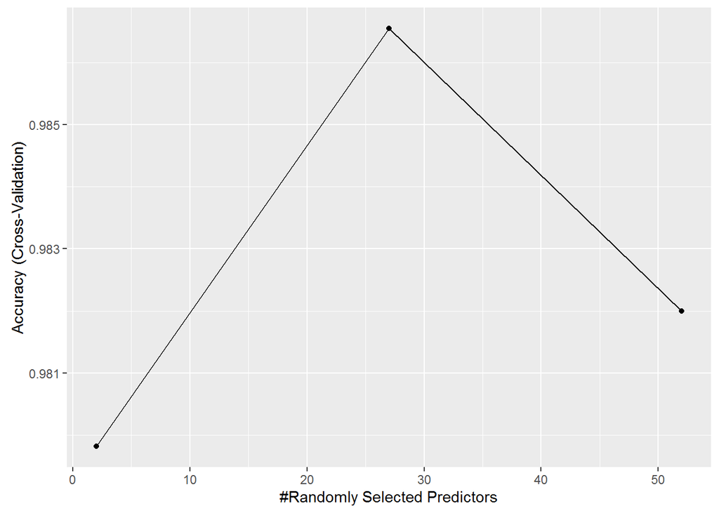

```r
cluster <- makeCluster(detectCores() - 1)
registerDoParallel(cluster)

traincontrol.rf <- trainControl(method = "cv",
                                number = 10,
                                allowParallel = TRUE)

set.seed(88)
mod.rf <- train(classe ~ ., data = training.set, method = "rf",
                            trControl = traincontrol.rf,
                            ntree = 10)

ggplot(mod.rf)
```

The accuracy of random forest method has reached 98.6%.

Second, boosted tree model is used for comparison. 10-fold cross-validation is used to select optimal parameter.

```r
traincontrol.gbm <- trainControl(method = "cv",
                                number = 10,
                                allowParallel = TRUE)

gbmGrid <-  expand.grid(interaction.depth = c(1, 5, 9),
                        n.trees = (1:3)*10,
                        shrinkage = 0.1,
                        n.minobsinnode = 20)

set.seed(88)
mod.gbm <- train(classe ~ ., data = training.set,
                 method = "gbm",
                 trControl = traincontrol.gbm,
                 verbose = FALSE,
                 tuneGrid = gbmGrid)
```

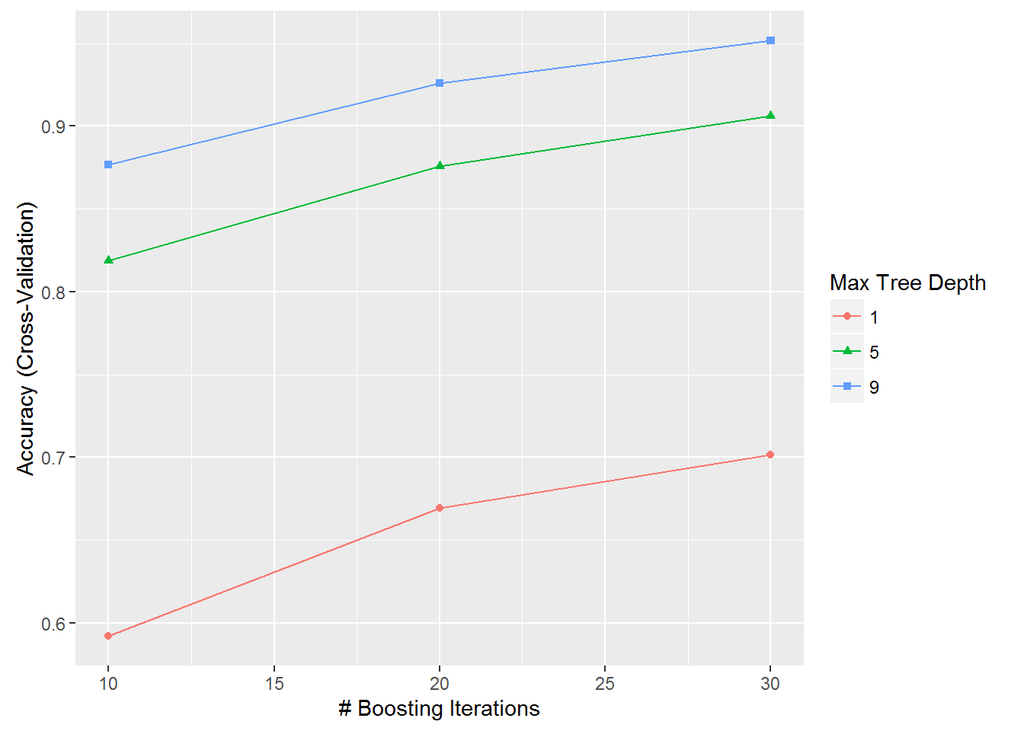

```r
ggplot(mod.gbm)
```

The accuracy of boosted tree model has reached 95%.

## Out Of Sample Error

The above 2 models are used in the test set to calculate out of sample error.

```r
result.rf <- table(predict(mod.rf, testing.set), testing.set$classe)
diagonal.index <- array(c(1:5, 1:5), dim = c(5, 2))
1 - sum(result.rf[diagonal.index]) / nrow(testing.set)
```

```
## [1] 0.008972268
```

Out of sample error of random forest model is 0.9%.

```r
result.gbm <- table(predict(mod.gbm, testing.set), testing.set$classe)
1 - sum(result.gbm[diagonal.index]) / nrow(testing.set)
```

```
## [1] 0.04669657
```

Out of sample error of boosted tree model is 4.7%.

## Choice of 2 models

According to out of sample error, random forest model is chosen for next prediction.

## Refine model

Before next prediction, training data and testing data are all used to refine the random forest model.

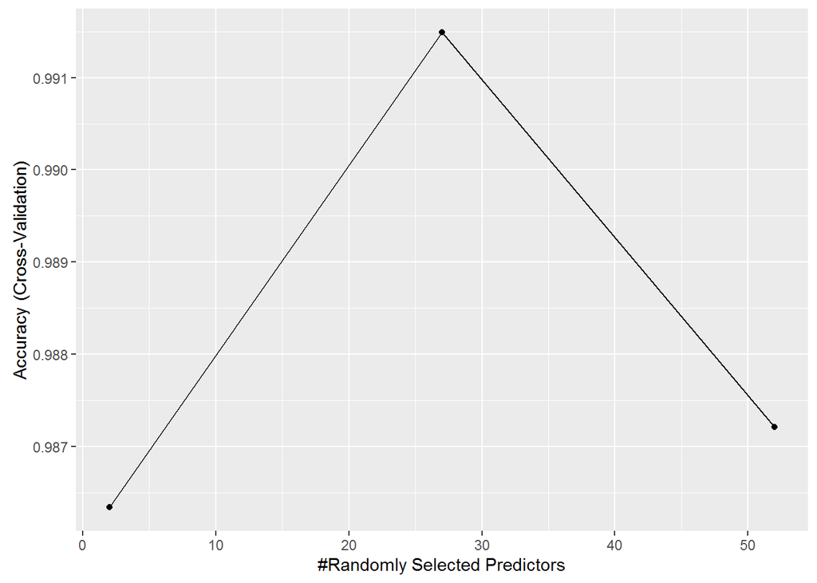

```r
all.data.set <- original.data[, final.col.name]
set.seed(88)
final.mod.rf <- train(classe ~ ., data = all.data.set, method = "rf",
                            trControl = traincontrol.rf,
                            ntree = 10)

###De-register parallel processing cluster
stopCluster(cluster)

ggplot(final.mod.rf)
```

## Predict 20 test cases

```r
data.for.prediction <- read.csv("pml-testing.csv")
col.name.for.prediction <- intersect(final.col.name, names(data.for.prediction))

result.of.prediction <- predict(final.mod.rf, data.for.prediction[, col.name.for.prediction])
result.of.prediction
```

```
##  [1] B A B A A E D B A A B C B A E E A B B B
## Levels: A B C D E
```